# The Derivative of a Function

Yuanting Lu

09/16/2020

## Definition

Recall that the derivative of a function $f(x)$ at $x=a$ is denoted by $f'(a)$,
$$f'(a) = \lim_{h\to 0}\dfrac{f(a+h) - f(a)}{(a + h) - a}= \lim_{h\to 0}\dfrac{f(a+h) - f(a)}{ h}.$$

The derivative of a function $f(x)$ at $x=a$ is denoted by $f'(a)$,
$$f'(x) = \lim_{h\to 0}\dfrac{f(x+h) - f(x)}{(x+h) - x}=\lim_{h\to 0}\dfrac{f(x+h) - f(x)}{h}.$$
The derivative of $y = f(x)$ is also commonly denoted as $\dfrac{dy}{dx}$.

**Example 1.** Let $f(x) = 2$. Find $f'(x)$.

**Example 2.** Let $f(x) = x^2$. Find $f'(x)$.

**Example 3.** Let $f(x) = x^3$. Find $f'(x)$.

**Example 4.** Let $f(x) = x^4$. Find $f'(x)$.

## Basic Rules

- **Power rule:** $(x^n)' = nx^{n-1}$.
- **Sum rule:** $\big(f(x) \pm g(x)\big)' = f'(x) \pm g'(x)$.
- **Constant multiple:** $\big(cf(x)\big)' = cf'(x)$.

## Differentiability

If the derivatives exist everywhere in the domain of $f(x)$, then we say $f(x)$ is differentiable.

Intuitively, differentiability suggests the function is not only continuous but also “smooth”.

**Is $f(x)=|x|$ differentiable at $x=0$?**

## Higher-order Derivatives

Let $y=f(x)$, the higher order derivatives of $f(x)$ are recursively defined as

$$f''(x) = \big(f'(x)\big)'$$

$$f'''(x) = \big(f''(x)\big)'$$

$$f^{(4)}(x) = \big(f'''(x)\big)'$$

$$\vdots$$

## Exponential Function

**Example 5** Let $f(x) = e^x$. Find $f'(x)$.

## Practice Problems

1. Find the derivative of the following functions by the definition of derivative.
   - $f(x)=x^2 - 2x^3$
   - $f(x)=\dfrac{1 - 2x}{3 + x}$
2. Find the derivative of the following functions by the derivative rules.
   - $f(x)=x^{5/3} - x^{2/3}$
   - $f(x)=3e^x+x^e$
   - $f(x)=e^{x+2} + 1$
   - $f(x)=\sqrt x - \frac 1 x + \frac{1}{x^2}$
   - $f(x)=\dfrac{x^2 + 4x + 3}{\sqrt x}$
   - $f(x)=\pi^2$
3. Identify $f(x)$ and $f'(x)$ on the following graphs.

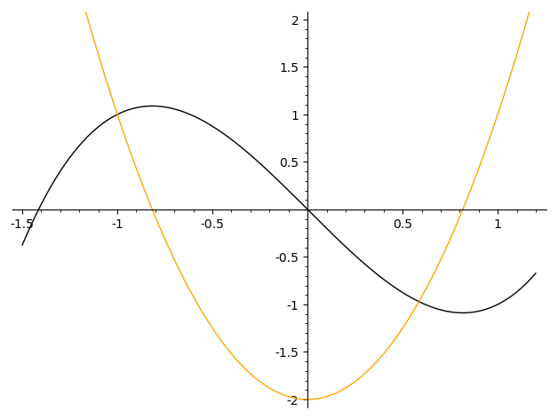

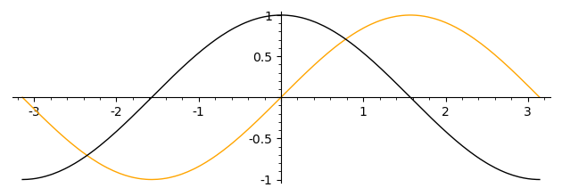

4. Identify $f(x), f'(x)$, and $f''(x)$ on the following graphs.

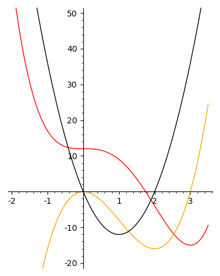

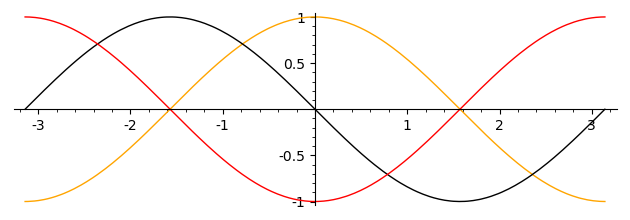